# Homework 1

# RMarkdown Syntax

**1.Show an example where the chunk option `cache = T` leads to a misleading answer.**

Caching option can be really usefull however it can sometimes lead to missleading. Indeed, if a code is time consuming due to long computations or plots that are taking too long to generate, we can use knitr caching to improve performance. However, if codes are linked between eachother, when we modify one we have to observe that the code with chunk cache option are also update, otherwise, the code will always take into consideration the old cache that we “register”.

**2. Simulate 1000 random samples from an exponential distribution with mean $\lambda = 1$ using the function `rexp()`. Store these 1000 values in a vector called `x`. Then, compute the empirical median, mean and variance of `x`. Are these results different from $log(2)/\lambda$, $1/\lambda$ and $1/\lambda^2$ (their respective theoretical values)? Is this result surprising? Justify your answer.**

To do so, we have use `set.seed` and `rexp()`function. We have the following table:

| Empirical values with lambda = 1 | x | log(2)/x | 1/x^2 |
| --- | --- | --- | --- |
| Median | 0.624 | 0.693 | 2.57e+00 |
| Mean | 0.974 | 5.948 | 8.54e+03 |
| Variance | 0.994 | 4073.937 | 6.52e+10 |

| Empirical values with lambda = 5 | x |
| --- | --- |
| Median | 0.142 |
| Mean | 0.204 |
| Variance | 0.042 |

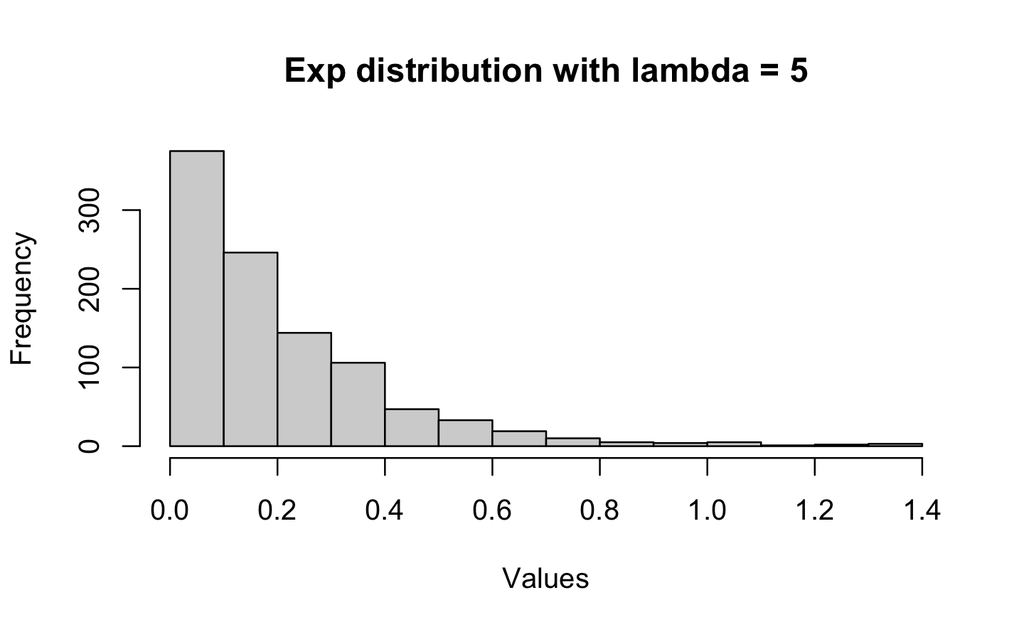

```r
hist(y,xlab='Values',main = 'Exp distribution with lambda = 5')
```

5. Include the following equation:

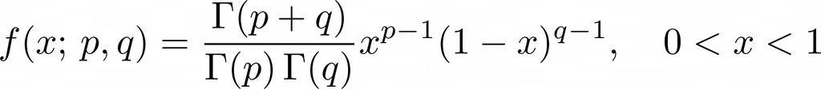

$$f(x;p,q) =
\frac{ \Gamma(p+q)}{\Gamma(p)\Gamma(q)}
x^{p-1}(1-x)^{q-1}, 0 < x < 1$$

6. Include the following in-line equation:

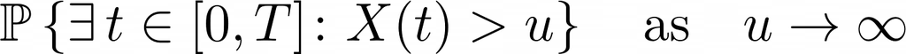

**7. Include the following text in purple: “It is change, continuing change, inevitable change, that is the dominant factor in society today. No sensible decision can be made any longer without….”, Isaac Asimov.**

“It is change, continuing change, inevitable change, that is the dominant factor in society today. No sensible decision can be made any longer without….”, Isaac Asimov.

**8. Include a “Click here” button with hide/unhide functionality.**

```r
hide("Click here")
```

[output not shown]

```r
unhide()
```

[output not shown]

**9. Include a “color box”” with some text.**

[output not shown]